## Prof. Dra. Agatha Sacramento Rodrigues

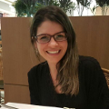

A produção bibliográfica completa da Prof. Agatha pode ser acessada no [Currículo Lattes](http://lattes.cnpq.br/3445977720574534). Além da produção científica, destaca-se a organização de eventos na área de Ciência de Dados, como o [#meetingdata](http://www.datascience.ufscar.br/meetingdata/index.php) em 2018 e o 1º Workshop on Data Science and Statistical Learning [(WDDSSL)](https://sites.google.com/view/wdssl2019/home) em 2019 , em que neste a prof. Agatha foi a presidente da comissão organizadora.

A professora é a coordenadora do projeto de extensão EnsinaR, que visa disseminar, ensinar e treinar a comunidade sobre o software R, um dos principais softwares da área.

A prof. Agatha tem trabalhado há muitos anos com pesquisadora Estatística em diferentes grupos de pesquisa da área da saúde, em um grupo multidisciplinar, propondo soluções e metodologias estatísticas para os problemas práticos da área. Vale ressaltar um projeto de 2018 realizado no Departamento de Radiologia da USP no qual o interesse consistia em aplicar técnicas de aprendizado de máquina para analisar dados radiômicos. Como resultado do envolvimento em grupos multidisciplinares, a professora é co-autora de 14 artigos de periódicos nas áreas de saúde.